# Machine Learning-WriteUp

Marcus Ross

2015/06/20

# Practical Machine Learning

## Abstract

With this assignment a machine for learning algorithm to predict activity quality is build. I uses data from activity monitors. The used data for this assignment can be found online here [1].

## The Data Retrieval

The dataset from [2] and [3] can be downloaded with these handy calls. It first checks if the file exists locally, if not it get´s downloaded:

```r
if (! file.exists('./training-data.csv')) {
  download.file('http://d396qusza40orc.cloudfront.net/predmachlearn/pml-training.csv',   destfile = './training-data.csv')
}
if (! file.exists('./testing-data.csv')) {
  download.file('http://d396qusza40orc.cloudfront.net/predmachlearn/pml-testing.csv',   destfile = './testing-data.csv')
}
```

The data is formated in CSV. Which can be easly loaded into R using read.csv:

```r
mldata.training <- read.csv('./training-data.csv')
mldata.testing  <- read.csv('./testing-data.csv')
```

## The Exploratory Analysis

The training set has 19.622 records. Each one has 160 variables.

```r
dim(mldata.training)
```

```
## [1] 19622   160
```

While inspecting the data, there is a lot of the 159 predictors missing in most of the records:

```r
sum(complete.cases(mldata.training))
```

```
## [1] 406
```

```r
head(mldata.training)
```

```
##   X user_name raw_timestamp_part_1 raw_timestamp_part_2   cvtd_timestamp
## 1 1  carlitos           1323084231               788290 05/12/2011 11:23
## 2 2  carlitos           1323084231               808298 05/12/2011 11:23
## 3 3  carlitos           1323084231               820366 05/12/2011 11:23
## 4 4  carlitos           1323084232               120339 05/12/2011 11:23
## 5 5  carlitos           1323084232               196328 05/12/2011 11:23
## 6 6  carlitos           1323084232               304277 05/12/2011 11:23
##   new_window num_window roll_belt pitch_belt yaw_belt total_accel_belt
## 1         no         11      1.41       8.07    -94.4                3
## 2         no         11      1.41       8.07    -94.4                3
## 3         no         11      1.42       8.07    -94.4                3
## 4         no         12      1.48       8.05    -94.4                3
## 5         no         12      1.48       8.07    -94.4                3
## 6         no         12      1.45       8.06    -94.4                3
##   kurtosis_roll_belt kurtosis_picth_belt kurtosis_yaw_belt
```

[output cut: 265 more lines]

Which means, there is a decision if all observations (including incomplete data) or less records with completeness are used. In this scenario all records are used. A second decision was, to not use the following variables: X, user_name, cvtd_timestamp, new_window, num_window, raw_timestamp_part1, raw_timestamp_part2 because there are not useful as potential confounders.

```r
included.cols <- c('roll_belt', 'pitch_belt', 'yaw_belt', 'total_accel_belt',
                   'gyros_belt_x', 'gyros_belt_y', 'gyros_belt_z',
                   'accel_belt_x', 'accel_belt_y', 'accel_belt_z',
                   'magnet_belt_x', 'magnet_belt_y', 'magnet_belt_z',
                   'roll_arm', 'pitch_arm', 'yaw_arm', 'total_accel_arm',
                   'gyros_arm_x', 'gyros_arm_y', 'gyros_arm_z',
                   'accel_arm_x', 'accel_arm_y', 'accel_arm_z',
                   'magnet_arm_x', 'magnet_arm_y', 'magnet_arm_z',
                   'roll_dumbbell', 'pitch_dumbbell', 'yaw_dumbbell', 'total_accel_dumbbell',
                   'gyros_dumbbell_x', 'gyros_dumbbell_y', 'gyros_dumbbell_z',
                   'accel_dumbbell_x', 'accel_dumbbell_y', 'accel_dumbbell_z',
                   'magnet_dumbbell_x', 'magnet_dumbbell_y', 'magnet_dumbbell_z',
                   'roll_forearm', 'pitch_forearm', 'yaw_forearm', 'total_accel_forearm',
                   'gyros_forearm_x', 'gyros_forearm_y', 'gyros_forearm_z',
                   'accel_forearm_x', 'accel_forearm_y', 'accel_forearm_z',
                   'magnet_forearm_x', 'magnet_forearm_y', 'magnet_forearm_z'
)
proc.mldata.testing <- mldata.testing[, included.cols]
included.cols <- c(included.cols, 'classe')
proc.mldata.training <- mldata.training[, included.cols]
```

The transformation will provide a data set of 19622 records each with 53 variables. One of those variables is the dependent variable “classe”

```r
dim(proc.mldata.training)
```

```
## [1] 19622    53
```

```r
sum(complete.cases(proc.mldata.training))
```

```
## [1] 19622
```

Now there is a clean data set. How are the relations in the data now?

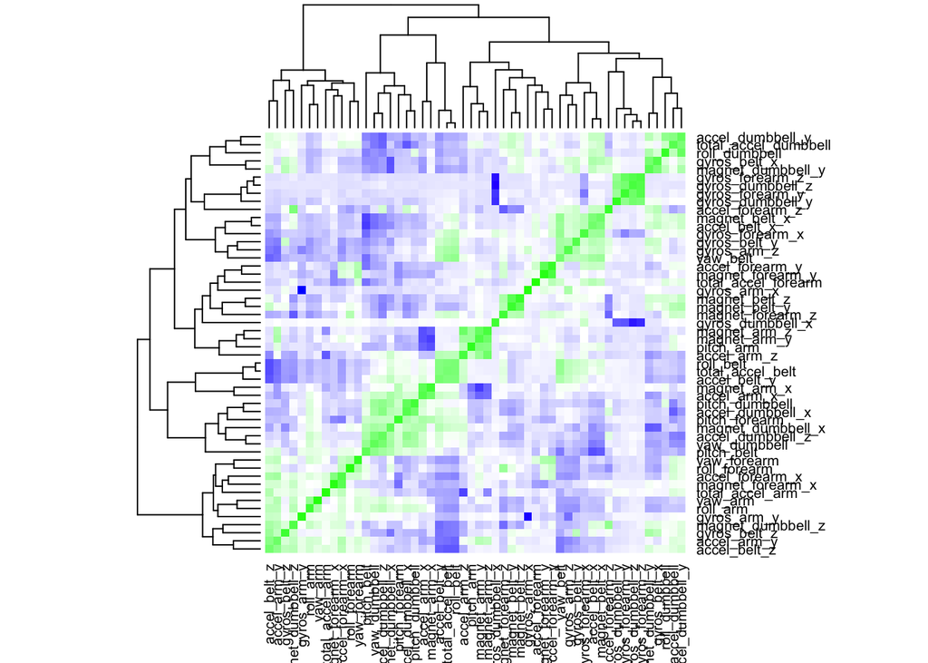

```r
pred.corr <- cor(proc.mldata.training[, names(proc.mldata.training) != 'classe'])
pal <- colorRampPalette(c('blue', 'white', 'green'))(n = 199)
heatmap(pred.corr, col = pal)
```

With using a heat map as a tool to find correlation. Nevertheless most of predictors do not exhibit high degree of correlation, but there are a few pairs of highly correlated variables!

There is an extreme cutoff of 0.98 (absolute value). Even then there are still two pairs of variables that lay above this threshold.

```r
which(pred.corr > 0.98 & pred.corr != 1)
```

```
## [1]   4 157
```

```r
pred.corr[which(pred.corr > 0.98 & pred.corr != 1)]
```

```
## [1] 0.9809241 0.9809241
```

```r
which(pred.corr < -0.98)
```

```
## [1]  10 469
```

```r
pred.corr[which(pred.corr < -0.98)]
```

```
## [1] -0.9920085 -0.9920085
```

The roll_belt predictor participates in both of these pairwise interactions:

```r
pred.corr['roll_belt', 'total_accel_belt']
```

```
## [1] 0.9809241
```

```r
pred.corr['roll_belt', 'accel_belt_z']
```

```
## [1] -0.9920085
```

```r
pred.corr['total_accel_belt', 'accel_belt_z']
```

```
## [1] -0.9749317
```

prevent bias: for bias prevention the model will discard the roll_belt variable.

```r
included.cols <- c('pitch_belt', 'yaw_belt', 'total_accel_belt',
                   'gyros_belt_x', 'gyros_belt_y', 'gyros_belt_z',
                   'accel_belt_x', 'accel_belt_y', 'accel_belt_z',
                   'magnet_belt_x', 'magnet_belt_y', 'magnet_belt_z',
                   'roll_arm', 'pitch_arm', 'yaw_arm', 'total_accel_arm',
                   'gyros_arm_x', 'gyros_arm_y', 'gyros_arm_z',
                   'accel_arm_x', 'accel_arm_y', 'accel_arm_z',
                   'magnet_arm_x', 'magnet_arm_y', 'magnet_arm_z',
                   'roll_dumbbell', 'pitch_dumbbell', 'yaw_dumbbell', 'total_accel_dumbbell',
                   'gyros_dumbbell_x', 'gyros_dumbbell_y', 'gyros_dumbbell_z',
                   'accel_dumbbell_x', 'accel_dumbbell_y', 'accel_dumbbell_z',
                   'magnet_dumbbell_x', 'magnet_dumbbell_y', 'magnet_dumbbell_z',
                   'roll_forearm', 'pitch_forearm', 'yaw_forearm', 'total_accel_forearm',
                   'gyros_forearm_x', 'gyros_forearm_y', 'gyros_forearm_z',
                   'accel_forearm_x', 'accel_forearm_y', 'accel_forearm_z',
                   'magnet_forearm_x', 'magnet_forearm_y', 'magnet_forearm_z'
)
proc.mldata.testing <- mldata.testing[, included.cols]
included.cols <- c(included.cols, 'classe')
proc.mldata.training <- mldata.training[, included.cols]
```

## Predictive Model

The forest algorithm 4 is been chosen for the building of a predictive model. It is, because it works good with non-linear models. It´s not needed to select parameter for this algorithm and run robust to correlated covariates and outliers. Futher more, the hign number of dimensions and observations makes random forest a good choice. For more details look at 4.

```r
library(randomForest)
library(caret)
library(grDevices)
```

The random forest classifier isn’t deterministic. For the matter of reproduction it is set to a random value (birth date of my child here).

```r
set.seed(310513)
```

The next step is to train the classifier. This is done by using all of the independent variables and 2048 trees.

```r
myModel <- randomForest(classe ~ ., data = proc.mldata.training, ntree = 2048)
```

```r
myModel
```

```
##
## Call:
##  randomForest(formula = classe ~ ., data = proc.mldata.training,      ntree = 2048)
##                Type of random forest: classification
##                      Number of trees: 2048
## No. of variables tried at each split: 7
##
##         OOB estimate of  error rate: 0.28%
## Confusion matrix:
##      A    B    C    D    E  class.error
## A 5578    1    0    0    1 0.0003584229
## B   11 3783    3    0    0 0.0036871214
## C    0   12 3409    1    0 0.0037989480
## D    0    0   20 3194    2 0.0068407960
## E    0    0    0    4 3603 0.0011089548
```

An out-of-bag error estimate of err-rate (0.28 percent) looks good. more information about the out-of-bag error vs. generalization error can be found at 4

```r
myModel$confusion
```

```
##      A    B    C    D    E  class.error
## A 5578    1    0    0    1 0.0003584229
## B   11 3783    3    0    0 0.0036871214
## C    0   12 3409    1    0 0.0037989480
## D    0    0   20 3194    2 0.0068407960
## E    0    0    0    4 3603 0.0011089548
```

The confusion matrix indicates that the model fits the training. Let’s have a look at the variable importance estimates obtained by the classifier training algorithm.

```r
importance <- varImp(myModel)
importance$Variable <- row.names(importance)
importance[order(importance$Overall, decreasing = T),]
```

```
##                         Overall             Variable
## yaw_belt             1091.88107             yaw_belt
## magnet_dumbbell_z     810.89645    magnet_dumbbell_z
## pitch_belt            795.84630           pitch_belt
## pitch_forearm         789.88741        pitch_forearm
## magnet_dumbbell_y     688.89383    magnet_dumbbell_y
## roll_forearm          625.11761         roll_forearm
## magnet_dumbbell_x     524.28621    magnet_dumbbell_x
## accel_belt_z          488.34758         accel_belt_z
## magnet_belt_z         468.51899        magnet_belt_z
## magnet_belt_y         453.95194        magnet_belt_y
## accel_dumbbell_y      424.25179     accel_dumbbell_y
## roll_dumbbell         422.09087        roll_dumbbell
## gyros_belt_z          397.17854         gyros_belt_z
## accel_dumbbell_z      350.74967     accel_dumbbell_z
## roll_arm              344.74446             roll_arm
## accel_forearm_x       330.26414      accel_forearm_x
## magnet_forearm_z      301.00727     magnet_forearm_z
## total_accel_dumbbell  284.51025 total_accel_dumbbell
## total_accel_belt      280.22982     total_accel_belt
## magnet_belt_x         275.50542        magnet_belt_x
## magnet_arm_x          271.15471         magnet_arm_x
## yaw_dumbbell          269.49609         yaw_dumbbell
## accel_forearm_z       258.90271      accel_forearm_z
## yaw_arm               258.03733              yaw_arm
## accel_dumbbell_x      254.71982     accel_dumbbell_x
## gyros_dumbbell_y      253.47514     gyros_dumbbell_y
## accel_arm_x           250.23889          accel_arm_x
## magnet_arm_y          241.31213         magnet_arm_y
## magnet_forearm_y      232.66834     magnet_forearm_y
## magnet_forearm_x      226.48590     magnet_forearm_x
## magnet_arm_z          194.57977         magnet_arm_z
## pitch_arm             190.14622            pitch_arm
## yaw_forearm           180.57574          yaw_forearm
## pitch_dumbbell        180.50402       pitch_dumbbell
## accel_arm_y           167.91574          accel_arm_y
## accel_belt_y          155.53058         accel_belt_y
## accel_forearm_y       150.14329      accel_forearm_y
## gyros_arm_y           149.95525          gyros_arm_y
## accel_arm_z           145.32552          accel_arm_z
## gyros_arm_x           144.03232          gyros_arm_x
## gyros_forearm_y       136.66990      gyros_forearm_y
## gyros_belt_y          135.56088         gyros_belt_y
## gyros_dumbbell_x      134.50556     gyros_dumbbell_x
## accel_belt_x          125.44377         accel_belt_x
## total_accel_forearm   117.41230  total_accel_forearm
## gyros_belt_x          114.54910         gyros_belt_x
## total_accel_arm       106.82321      total_accel_arm
## gyros_dumbbell_z       88.76060     gyros_dumbbell_z
## gyros_forearm_z        88.13628      gyros_forearm_z
## gyros_forearm_x        80.93345      gyros_forearm_x
## gyros_arm_z            60.69421          gyros_arm_z
```

Qualitycheck: The models use prediction against the testing data set provided by coursera [2]

```r
predict(myModel, proc.mldata.testing)
```

```
##  1  2  3  4  5  6  7  8  9 10 11 12 13 14 15 16 17 18 19 20
##  B  A  B  A  A  E  D  B  A  A  B  C  B  A  E  E  A  B  B  B
## Levels: A B C D E
```

## References

1. http://groupware.les.inf.puc-rio.br/har (section off the Weight Lifting Exercise Dataset).
2. https://d396qusza40orc.cloudfront.net/predmachlearn/pml-testing.csv
3. https://d396qusza40orc.cloudfront.net/predmachlearn/pml-training.csv
4. Breiman, L. (2001). Random forests. Machine learning http://oz.berkeley.edu/~breiman/randomforest2001.pdf